# Data Visualization with R

Miles Whedbee

2022-07-05

Rob Kabacoff: R is an amazing platform for data analysis, capable of creating almost any type of graph. The text relies heavily on the ggplot2 package for graphics, but other approaches are covered as well.

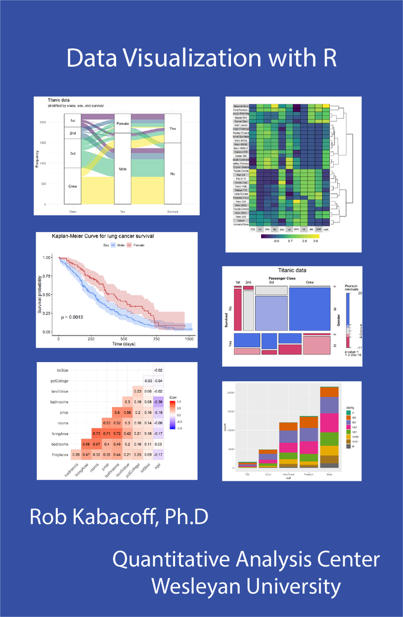

https://rkabacoff.github.io/datavis/index.html

## Importing Data

R can import data from almost any source, including text files, excel spreadsheets, statistical packages, and database management systems. (Kabacoff, 2020)

CSV format from “salaries”

“rank”,“discipline”,“yrs.since.phd”,“yrs.service”,“sex”,“salary”  
“Prof”,“B”,19,18,“Male”,139750  
“Prof”,“B”,20,16,“Male”,173200  
“AsstProf”,“B”,4,3,“Male”,79750  
“Prof”,“B”,45,39,“Male”,115000  
“Prof”,“B”,40,41,“Male”,141500  
“AssocProf”,“B”,6,6,“Male”,97000

```r
#install.packages("ggplot2")
library(ggplot2)

#data(msleep, package="ggplot2")
#write.csv(msleep, file = "../Data/msleep.csv", row.names = F)

read.csv(file = "../Data/msleep.csv") -> msleep

#excel
#library(readxl)
#read_excel("path/to/data/HERE", sheet = 1)
```

## Data Cleaning

Can be quite time consuming, especially for complex datasets! Could spend entire hour on data cleaning and reshaping. These functions together are sufficient for most data cleaning/restructuring needs:

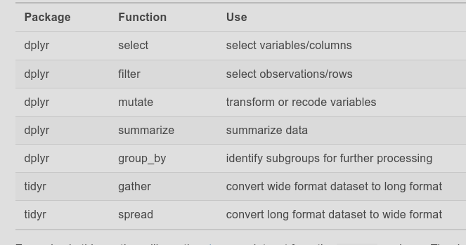

### Long Vs Wide Format

Different plots require different formats, either wide or long. R functions often expect long format, other programs may be wide-based, such as SPSS.

```r
library(tidyr)

# from R Cookbook
olddata_wide <- read.table(header=TRUE, text='
 subject sex control cond1 cond2
       1   M     7.9  12.3  10.7
       2   F     6.3  10.6  11.1
       3   F     9.5  13.1  13.8
       4   M    11.5  13.4  12.9
')

# Make sure the subject column is a factor
olddata_wide$subject <- factor(olddata_wide$subject)

# pivot_longer() is new standard
data_long <- gather(olddata_wide, condition, measurement, control:cond2, factor_key=TRUE)
```

### Selecting variables (columns)

```r
library(dplyr)
# select taxa variables store in new DF
msleep %>% select(name, genus, order) -> taxa.df

# select range of variables, numerical only
msleep %>% select(sleep_total:bodywt) -> NumOnly.df
```

### Filtering observations (rows)

```r
# filter and store endagered (en) status only
msleep %>% filter(conservation == 'en') -> en_only.df

# boolean logic, pull out herbivores of least concern
msleep %>% filter(conservation == 'lc' & vore == 'herbi') -> herbi_lc.df
```

### Missing values (NAs)

Real data are likely to contain missing values. We’ll cover two basic approaches to dealing with missing data: feature selection and listwise deletion.

#### Feature selection

```r
# what is the proportion of missing data for each variable?
pctmiss <- colSums(is.na(msleep))/nrow(msleep)
round(pctmiss, 2)
```

```
##         name        genus         vore        order conservation  sleep_total
##         0.00         0.00         0.08         0.00         0.35         0.00
##    sleep_rem  sleep_cycle        awake      brainwt       bodywt
##         0.27         0.61         0.00         0.33         0.00
```

sleep_cycle is missing 61% of it’s values, you can decide if you want to drop it.

#### Listwise deletion

Listwise deletion involves deleting observations (rows) that contain missing values on *any* of the variables of interest.

```r
# Create a dataset containing genus, vore, and conservation.
# Delete any rows containing missing data.
newdata <- select(msleep, genus, vore, conservation)
newdata <- na.omit(newdata)
head(newdata)
```

```
##         genus  vore conservation
## 1    Acinonyx carni           lc
## 3  Aplodontia herbi           nt
## 4     Blarina  omni           lc
## 5         Bos herbi domesticated
## 7 Callorhinus carni           vu
## 9       Canis carni domesticated
```

## Univariate Analysis

Univariate graphs plot the distribution of data from a single variable. The variable can be categorical (e.g., race, sex) or quantitative (e.g., age, weight).

### Categorical

The distribution of a single categorical variable is typically plotted with a bar chart, a pie chart, or (less commonly) a tree map. (Kabacoff, 2020)

Linear distances, e.g. barchart are much easier for the human eye to discern than areas within a pie chart… Try not to use pie charts.

### Bar Chart

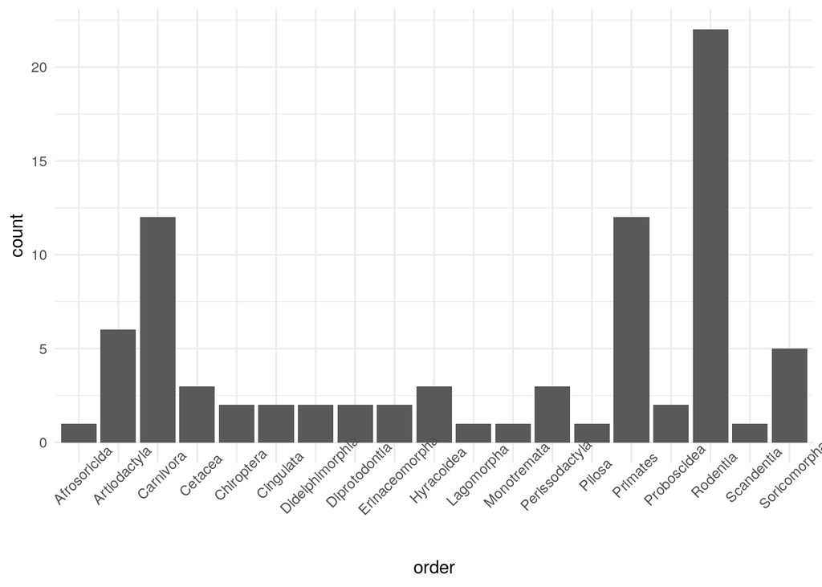

```r
# specify dataset and mapping
library(ggplot2)

# N of species in each order
ggplot(data = msleep, mapping = aes(x = order)) +
    geom_bar() +
  theme_minimal() +
  theme(axis.text.x = element_text(angle = 45))
```

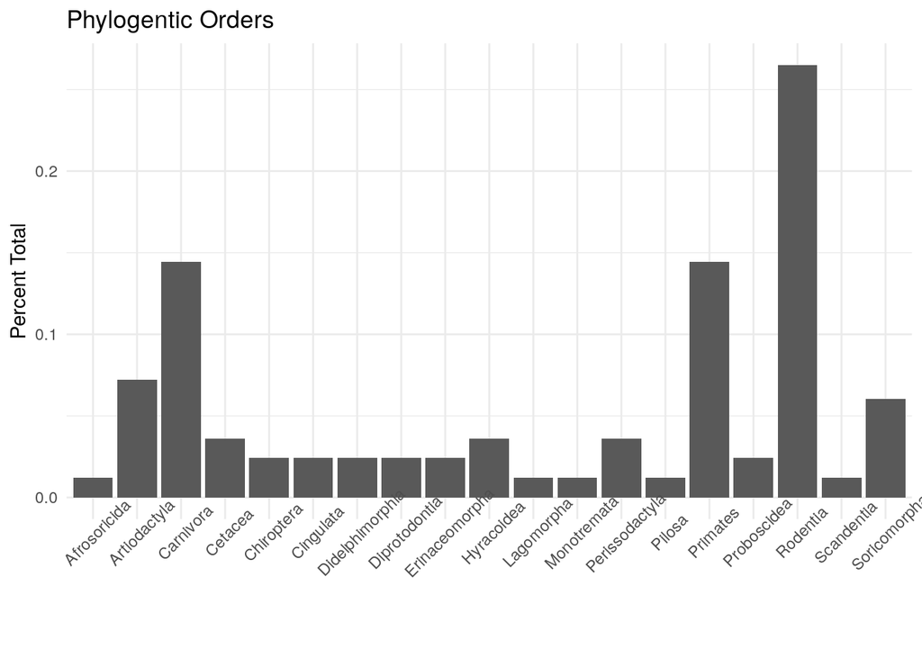

```r
# calc percents from counts and plot
ggplot(data = msleep,
       aes(x = order,
           y = ..count.. / sum(..count..))) +
       geom_bar() +
       labs(x = "", y = "Percent Total", title  = "Phylogentic Orders") +
       theme_minimal() +
       theme(axis.text.x = element_text(angle = 45))
```

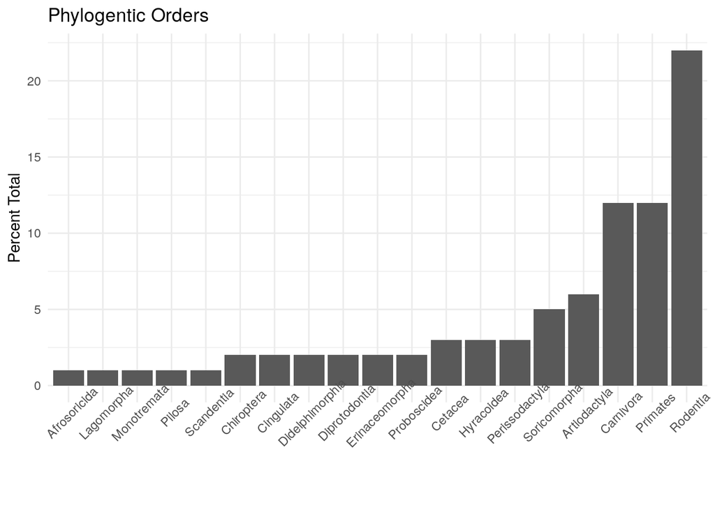

```r
# Organize columns by frequenc
msleep %>% count(order) -> plotdata

ggplot(data = plotdata,
       aes(x = reorder(order, n), y = n)) +
       geom_bar(stat = "identity") +
       labs(x = "", y = "Percent Total", title  = "Phylogentic Orders") +
       theme_minimal() +
       theme(axis.text.x = element_text(angle = 45))
```

## Quantitative vs. Quantitative

The relationship between two quantitative variables is typically displayed using scatterplots and line graphs.

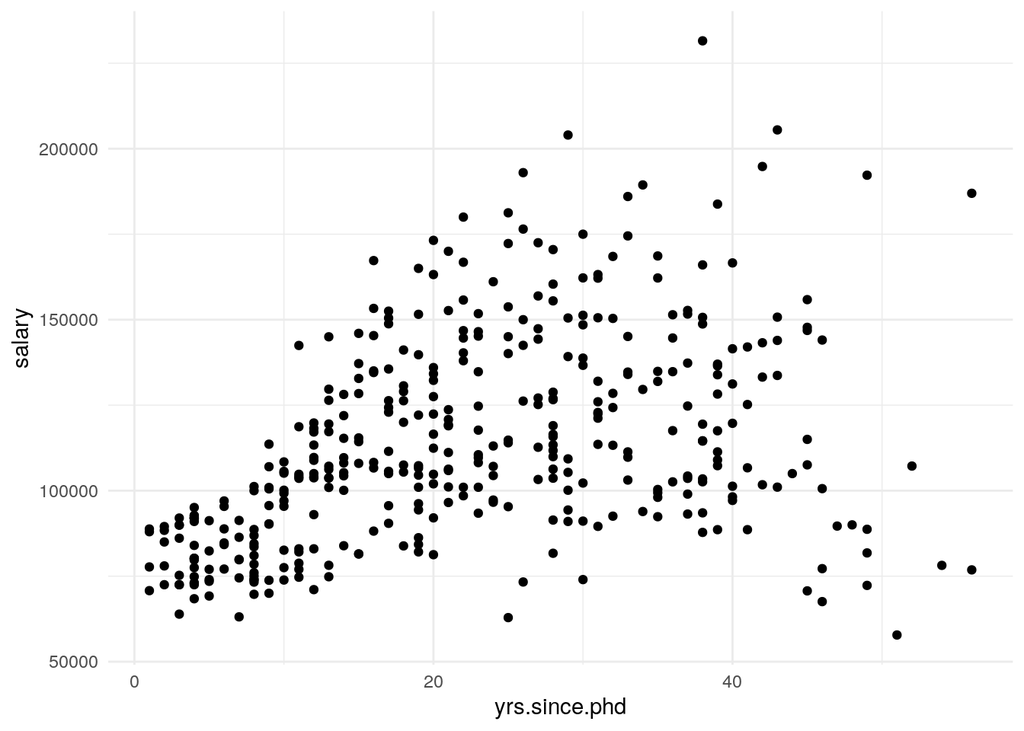

```r
# scatterplot of
# simple scatterplot
#install.packages("car")

library(ggplot2)
data("Salaries", package = "carData")

ggplot(Salaries,
       aes(x = yrs.since.phd,
           y = salary)) +
  geom_point() +
  theme_minimal()
```

`geom_point` options can be used to change the

- `color` - point color
- `size` - point size
- `shape` - point shape
- `alpha` - point transparency. Transparency ranges from 0 (transparent) to 1 (opaque), and is a useful parameter when points overlap.

The functions `scale_x_continuous` and `scale_y_continuous` control the scaling on *x* and *y* axes respectively.

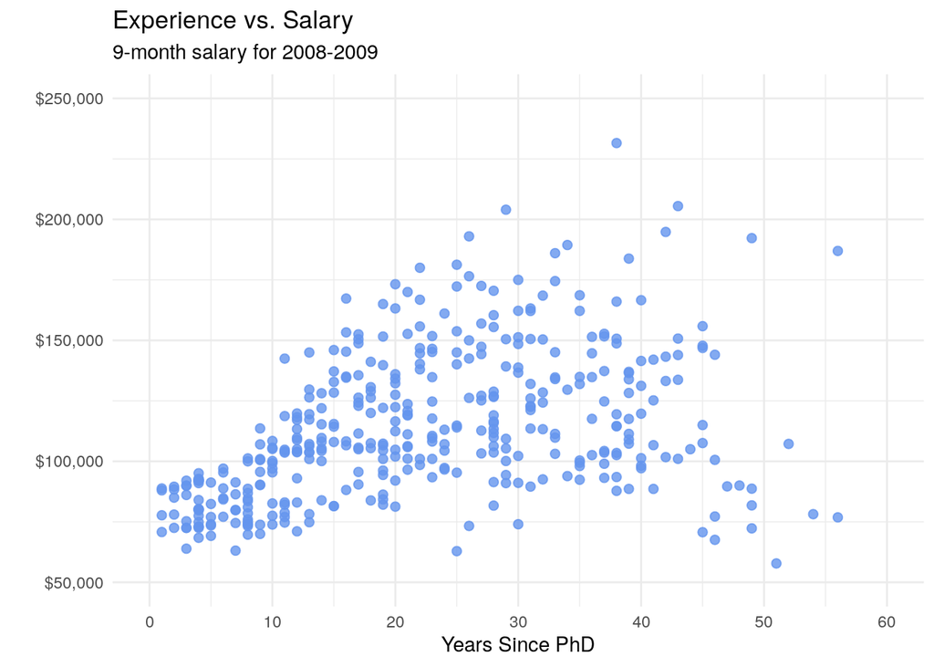

```r
ggplot(Salaries,
       aes(x = yrs.since.phd,
           y = salary)) +
  geom_point(color="cornflowerblue",
             size = 2,
             alpha=.8) +
  scale_y_continuous(label = scales::dollar,
                     limits = c(50000, 250000)) +
  scale_x_continuous(breaks = seq(0, 60, 10),
                     limits=c(0, 60)) +
  labs(x = "Years Since PhD",
       y = "",
       title = "Experience vs. Salary",
       subtitle = "9-month salary for 2008-2009") +
  theme_minimal()
```

#### Adding best fit lines

It is often useful to summarize the relationship displayed in the scatterplot, using a best fit line. Many types of lines are supported, including linear, polynomial, and nonparametric (loess). By default, 95% confidence limits for these lines are displayed.

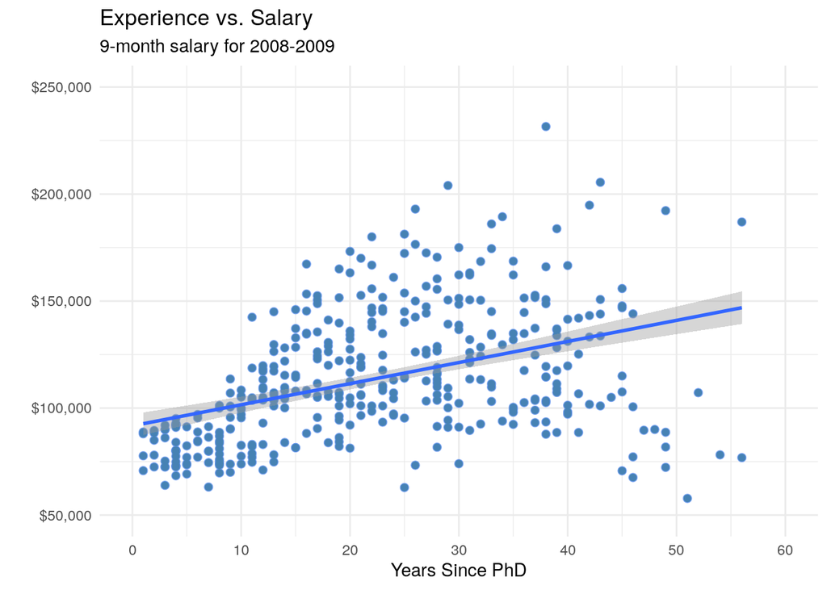

```r
ggplot(Salaries,
       aes(x = yrs.since.phd,
           y = salary)) +
  geom_point(color="cornflowerblue",
             size = 2,
             alpha=.8) +
  scale_y_continuous(label = scales::dollar,
                     limits = c(50000, 250000)) +
  scale_x_continuous(breaks = seq(0, 60, 10),
                     limits=c(0, 60)) +
  labs(x = "Years Since PhD",
       y = "",
       title = "Experience vs. Salary",
       subtitle = "9-month salary for 2008-2009") +
  geom_point(color= "steelblue") +
  geom_smooth(method = "lm") +
  theme_minimal()
```

Figure 4.9: Scatterplot with linear fit line

Clearly, salary increases with experience. However, there seems to be a dip at the right end - professors with significant experience, earning lower salaries. A straight line does not capture this non-linear effect. A line with a bend will fit better here.

Typically either a quadratic (one bend), or cubic (two bends) line is used. It is rarely necessary to use a higher order( >3 ) polynomials. Applying a quadratic fit to the salary dataset produces the following result.

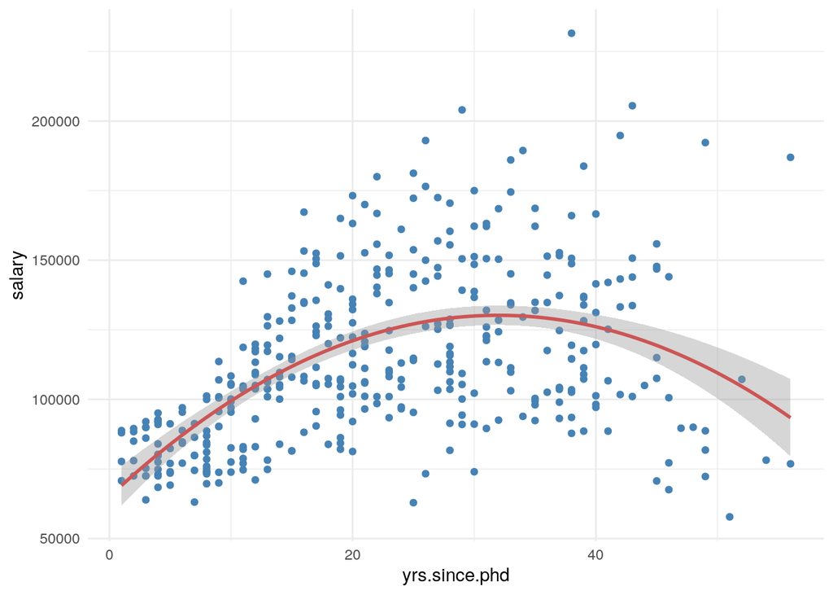

```r
# scatterplot with quadratic line of best fit
ggplot(Salaries,
       aes(x = yrs.since.phd,
           y = salary)) +
  geom_point(color= "steelblue") +
  geom_smooth(method = "lm",
              formula = y ~ poly(x, 2),
              color = "indianred3") +
  theme_minimal()
```

## Correlation plots

Correlation plots help you to visualize the pairwise relationships between a set of quantitative variables by displaying their correlations using color or shading.

Consider the [Saratoga Houses](https://rkabacoff.github.io/datavis/Models.html#SaratogaHouses) dataset, which contains the sale price and characteristics of Saratoga County, NY homes in 2006. In order to explore the relationships among the quantitative variables, we can calculate the Pearson Product-Moment [correlation coefficients](http://www.statisticshowto.com/probability-and-statistics/correlation-coefficient-formula/).

```r
#install.packages("mosaicData")
data(SaratogaHouses, package="mosaicData")

df <- dplyr::select_if(SaratogaHouses, is.numeric)
# calulate the correlations
r <- cor(df, use="complete.obs")
round(r,2)
```

```
##            price lotSize   age landValue livingArea pctCollege bedrooms
## price       1.00    0.16 -0.19      0.58       0.71       0.20     0.40
## lotSize     0.16    1.00 -0.02      0.06       0.16      -0.03     0.11
## age        -0.19   -0.02  1.00     -0.02      -0.17      -0.04     0.03
## landValue   0.58    0.06 -0.02      1.00       0.42       0.23     0.20
## livingArea  0.71    0.16 -0.17      0.42       1.00       0.21     0.66
## pctCollege  0.20   -0.03 -0.04      0.23       0.21       1.00     0.16
## bedrooms    0.40    0.11  0.03      0.20       0.66       0.16     1.00
## fireplaces  0.38    0.09 -0.17      0.21       0.47       0.25     0.28
## bathrooms   0.60    0.08 -0.36      0.30       0.72       0.18     0.46
## rooms       0.53    0.14 -0.08      0.30       0.73       0.16     0.67
##            fireplaces bathrooms rooms
## price            0.38      0.60  0.53
## lotSize          0.09      0.08  0.14
## age             -0.17     -0.36 -0.08
## landValue        0.21      0.30  0.30
## livingArea       0.47      0.72  0.73
## pctCollege       0.25      0.18  0.16
## bedrooms         0.28      0.46  0.67
## fireplaces       1.00      0.44  0.32
## bathrooms        0.44      1.00  0.52
## rooms            0.32      0.52  1.00
```

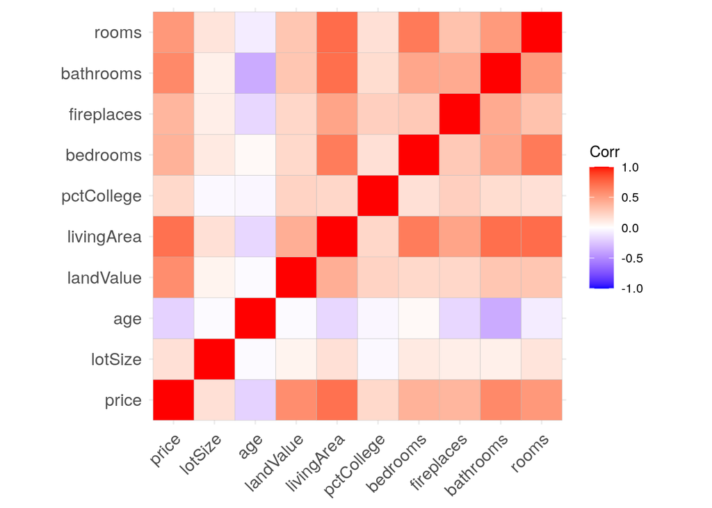

```r
#install.packages("ggcorrplot")
library(ggcorrplot)
ggcorrplot(r)
```

#### Correlation matrix

From the graph, an increase in number of bathrooms and living area are associated with increased price, while older homes tend to be less expensive. Older homes also tend to have fewer bathrooms.

The [`ggcorrplot`](https://www.rdocumentation.org/packages/ggcorrplot/versions/0.1.1/topics/ggcorrplot) function has a number of options for customizing the output. For example

- `hc.order = TRUE` reorders the variables, placing variables with similar correlation patterns together.
- `type = "lower"` plots the lower portion of the correlation matrix.
- `lab = TRUE` overlays the correlation coefficients (as text) on the plot.

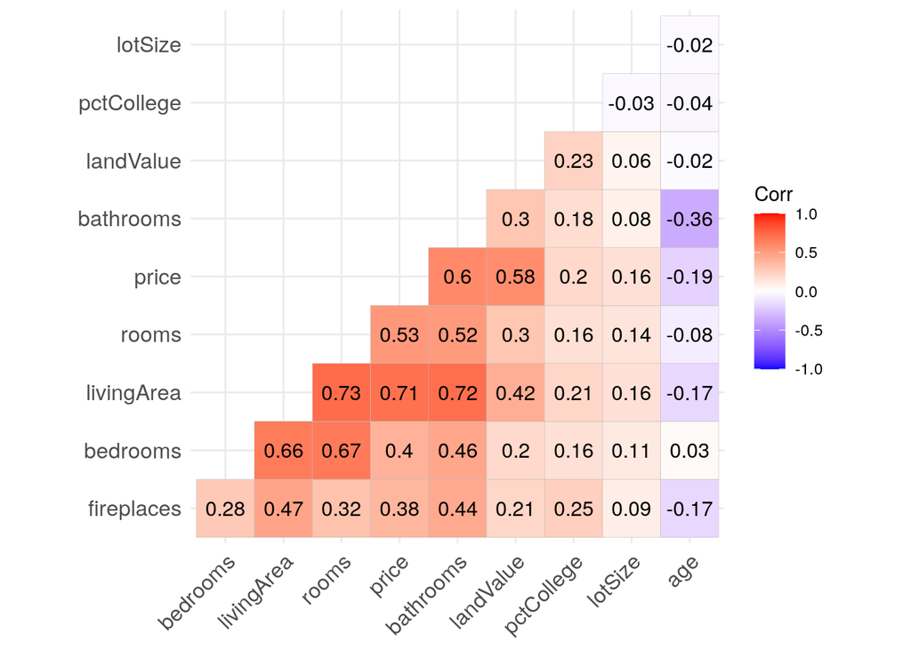

```r
ggcorrplot(r,
           hc.order = TRUE,
           type = "lower",
           lab = TRUE)
```

## Time-series data visualization example

Adapted from https://rkabacoff.github.io/ data generated by M. Rodriguez-Santiago

### TIME SERIES INTRODUCTION

A time series is a set of quantitative values obtained at successive time points. The intervals between time points (e.g., hours, days, weeks, months, or years) are usually equal.

### online source for how R handles dates:

https://stats.oarc.ucla.edu/r/faq/how-does-r-handle-date-values

### GENERAL DATE INFORMATION

```r
# print today's date
today <- Sys.Date()
format(today, format="%B %d %Y")
```

```
## [1] "July 06 2022"
```

```r
# convert character data to dates
strDates <- c("01/05/1965", "08/16/1975")
dates <- as.Date(strDates, "%m/%d/%Y")

#as.Date(x, "format")
#where x is the character data and format gives the appropriate format
```

```r
#### R DATASET EXAMPLE ---------------------------------------------------------
# 'economics' dataset taken from 1967 to 2015

## loading packages
library(ggplot2)
library(scales) #?scales

## explore the data frame
colnames(economics)  #to see names of all columns in data frame
```

```
## [1] "date"     "pce"      "pop"      "psavert"  "uempmed"  "unemploy"
```

```r
dim(economics)  #dimensions of dataframe (rows x columns)
```

```
## [1] 574   6
```

```r
head(economics)  #first 6 rows
```

```
## # A tibble: 6 × 6
##   date         pce    pop psavert uempmed unemploy
##   <date>     <dbl>  <dbl>   <dbl>   <dbl>    <dbl>
## 1 1967-07-01  507. 198712    12.6     4.5     2944
## 2 1967-08-01  510. 198911    12.6     4.7     2945
## 3 1967-09-01  516. 199113    11.9     4.6     2958
## 4 1967-10-01  512. 199311    12.9     4.9     3143
## 5 1967-11-01  517. 199498    12.8     4.7     3066
## 6 1967-12-01  525. 199657    11.8     4.8     3018
```

```r
tail(economics)  #last 6 rows
```

```
## # A tibble: 6 × 6
##   date          pce     pop psavert uempmed unemploy
##   <date>      <dbl>   <dbl>   <dbl>   <dbl>    <dbl>
## 1 2014-11-01 12051. 319564.     7.3    13       9090
## 2 2014-12-01 12062  319746.     7.6    12.9     8717
## 3 2015-01-01 12046  319929.     7.7    13.2     8903
## 4 2015-02-01 12082. 320075.     7.9    12.9     8610
## 5 2015-03-01 12158. 320231.     7.4    12       8504
## 6 2015-04-01 12194. 320402.     7.6    11.5     8526
```

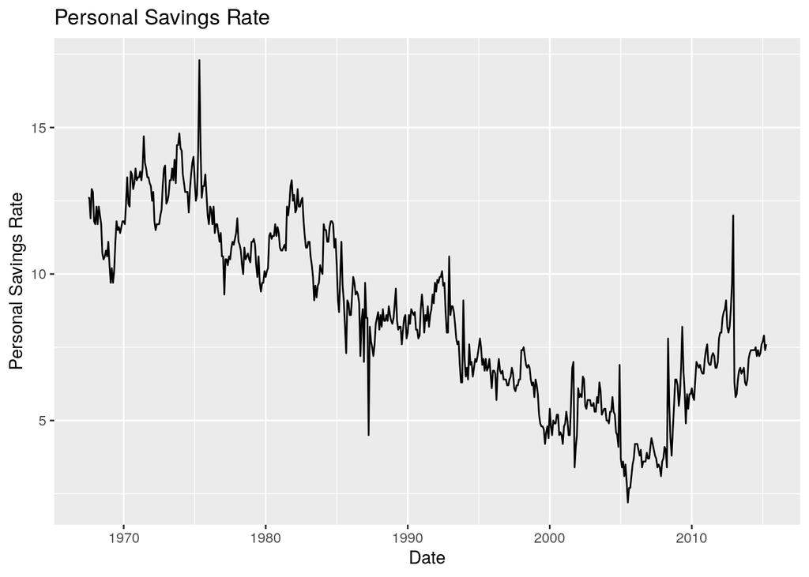

```r
## simple graph
ggplot(economics, aes(x = date, y = psavert)) +
  geom_line() +
  labs(title = "Personal Savings Rate",
       x = "Date",
       y = "Personal Savings Rate")
```

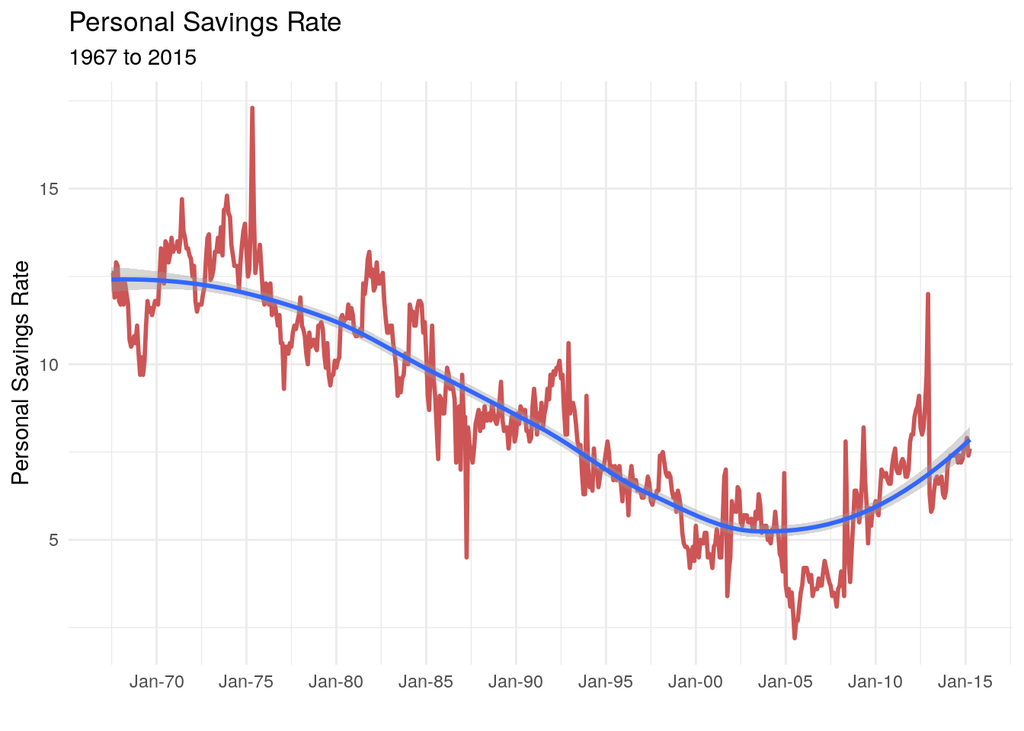

```r
## fancy graph
#scale_x_date: used to reformat dates
#date variable is class date and not class character
ggplot(economics, aes(x = date, y = psavert)) +
  geom_line(color = "indianred3",
            size=1 ) +
  geom_smooth() +
  scale_x_date(date_breaks = '5 years',
               labels = date_format("%b-%y")) +
  labs(title = "Personal Savings Rate",
       subtitle = "1967 to 2015",
       x = "",
       y = "Personal Savings Rate") +
  theme_minimal()
```

```r
### GENERAL NOTES ON BIO DATASET EXAMPLE ---------------------------------------

# data example is a subset from a larger dataset
# data unpublished - do not distribute widely

# "group" contains 10 fish to start, 5 males and 5 females
# experiment consists of two phases, acclimation and learning
# stable.flux means groups were kept together during acclimation
# "day" of experiment
# "size.rank" males were ranked by standard length on day 0
# "aggressive.beh" total count when individual initiated aggressive beh (male to male)
# "submissive.beh" total count when individual swam away from aggressive encounter
# "courtship" total courtship behavior count (male to female)


##### LOADING PACKAGES ---------------------------------------------------------
```

```r
library(dplyr)
library(ggplot2)

##### IMPORT DATA & VARIABLE TYPE CHANGE ---------------------------------------

beh <- read.csv("../Data/beh_for_R_demo.csv", header = TRUE)

beh$day <- as.factor(beh$day)
beh$trial <- as.factor(beh$trial)

#### LINE PLOT OF AGGRESSIVE BEHAVIORS -----------------------------------------
## subset one group

colnames(beh)
```

```
##  [1] "group"          "round"          "treatment"      "phase"
##  [5] "day"            "trial"          "animal.id"      "size.rank"
##  [9] "designation"    "aggressive.beh" "submissive.beh" "courtship.beh"
```

```r
dim(beh)
```

```
## [1] 797  12
```

```r
unique(beh$animal.id)  #to see characters within animal.id variable
```

```
##  [1] "n92"  "n88"  "n77"  "n64"  "n104" "n95"  "n74"  "n65"  "n110" "n105"
## [11] "n83"  ""
```

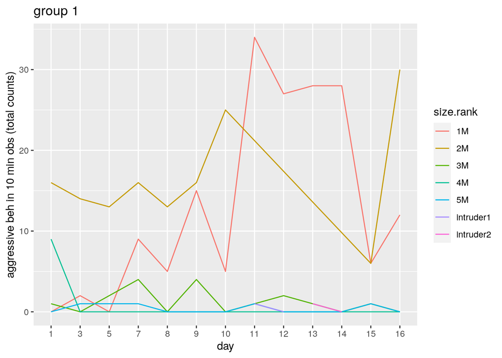

```r
group1 <- beh %>%
  filter(group == "NETG07")

## line plot of aggressive behavior over days

ggplot(group1, aes(x = day, y = aggressive.beh, group=size.rank, color=size.rank)) +
  geom_line() +
  labs(title = "group 1",
       x = "day",
       y = "aggressive beh in 10 min obs (total counts)")
```

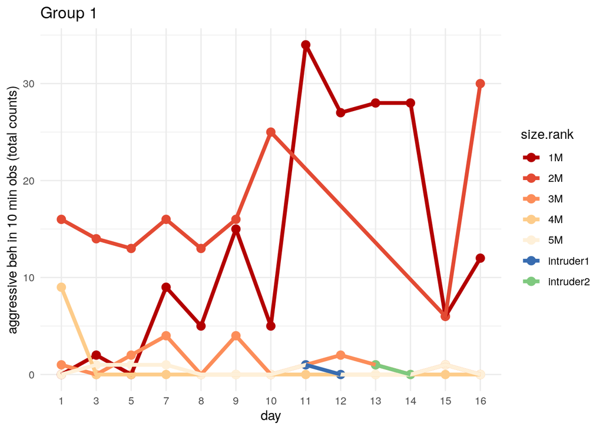

```r
## fancy line plot

ggplot(group1, aes(x = day, y = aggressive.beh, group=size.rank, color=size.rank)) +
  geom_point(size=3) +
  geom_line(size=1.5) +
  scale_color_manual(values = c("#b30000","#e34a33","#fc8d59","#fdcc8a","#fef0d9","#386cb0","#7fc97f")) +
  labs(title = "Group 1",
       x = "day",
       y = "aggressive beh in 10 min obs (total counts)") +
  theme_minimal()
```